# Weather events with the greatest health and economic impacts across the United States, from 1995-2011

# Synopsis

This report aims to answer the question, “which types of storms have the greatest health and economic impact?”

Data was gathered from the U.S. National Oceanic and Atmospheric Administration (NOAA) storm database. Specifically, data indicating the type, date, numbers of fatalities and injuries, and extent of property and crop damage for a given storm was used to answer the question.

Finally, deeper examination of the Hurricane/Typhoon category shows that the economic damage caused by Hurricane/Typhoons from 1995-2011 was most likely skewed by one hurricane which ended on August 29, 2005 - which is also the end date of Hurricane Katrina.

The code and figures providing evidence and more detailed discussion of the possible conclusions suggested here are found below.

## Results

The data was analyzed for overall damage to health - by fatality or injury - and overall damage to economy - through property or crop damage. A panel of histograms was created (using ggplot2) to look at the sum of health vs. economic damages caused by a given weather event.

NOTE: The below code allows for manipulation of the x-axis, whereby the histogram bars are ordered in decreasing frequency.

```r
#Use for generating factor levels when ordering weather events in qplot

healthSums <- stormdata[DamageType == "Health"][, sum(Damage), by = Event]
economicSums <- stormdata[DamageType == "Economic"][, sum(Damage), by = Event]
sums <- merge(healthSums, economicSums, by = "Event")
setnames(sums, old = c("V1.x", "V1.y"), new = c("healthSums", "economicSums"))
stormdata <- merge(stormdata, sums, by = "Event")

count <- data.frame(table(stormdata$Event))
setnames(count, old = "Var1", new = "Event")
stormdata <- merge(x = stormdata, y = count, by = "Event")
```

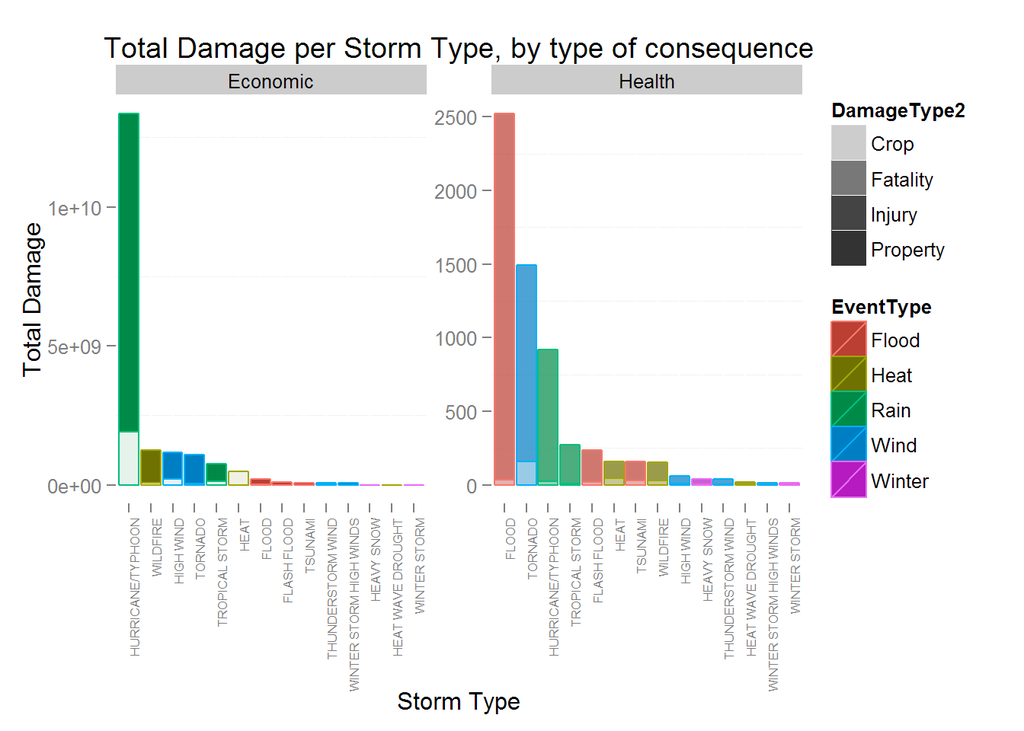

```r
healthFactLvls <- sums[order(healthSums, decreasing = TRUE)]$Event
economicFactLvls <- sums[order(economicSums, decreasing = TRUE)]$Event

ggplot(data = stormdata, aes(fill = EventType, alpha = DamageType2,
                             weight = Damage, color = EventType)) +
        geom_bar(data = stormdata[DamageType == "Health"],
                 aes(x = factor(Event, levels = healthFactLvls))) +
        geom_bar(data = stormdata[DamageType == "Economic"],
                 aes(x = factor(Event, levels = economicFactLvls))) +
        facet_wrap(~ DamageType, scales = "free") +
        theme(axis.text.x = element_text(angle = 90, hjust = 1, size = 6),
              panel.background = element_rect("white")) +
        scale_fill_hue(l = 45) +
        labs(x = "Storm Type",
             y = "Total Damage",
             title = "Total Damage per Storm Type, by type of consequence")
```

In the above plots, total damage, expressed in dollars for the economic data and counts for the health data, is graphed against weather event. Each bar is stacked to show the sum of crop and property damage in the case of the economic data and fatalities and injuries in the case of the health data. Shading has been applied to demarcate these stacked values. Further, colors have been applied to the umbrella categories of weather events: Flood, Heat, Rain, Wind, and Winter.

It is interesting to note that the most harmful weather events with respect to human lives are not the most harmful weather events with respect to property. Further, the data reflecting economic consequences is heavily skewed right, begging the question as to what has caused the skew. Is the **number** of hurricanes in the US from 1995-2011 dramatically greater than any other weather event, or is the **impact** of a few hurricanes large enough to offset that of other events?

To address this question, the data was graphed in a different manner, to reflect the frequency of each weather event as well.

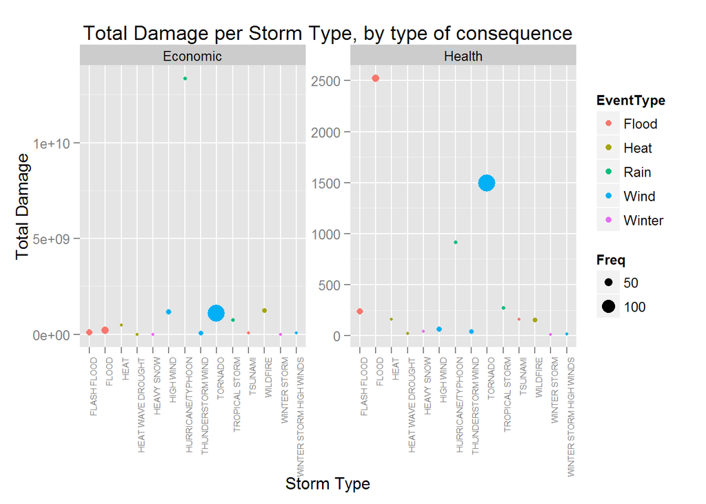

```r
ggplot(stormdata) +
        geom_point(data = stormdata[DamageType == "Health"],
                   aes(x = Event, y = healthSums, color = EventType,
                       size = Freq)) +
        geom_point(data = stormdata[DamageType == "Economic"],
                   aes(x = Event, y = economicSums, color = EventType,
                       size = Freq)) +
        facet_wrap(~ DamageType, scales = "free") +
        theme(axis.text.x = element_text(angle = 90, hjust = 1, size = 6)) +
        scale_fill_hue(l = 45) +
        labs(x = "Storm Type",
             y = "Total Damage",
             title = "Total Damage per Storm Type, by type of consequence")
```

In the above plots, total damages are again plotted against weather event. In this graph, color indicates the umbrella categories of weather events, and the size of each point indicates the frequency of a given weather event.

The graphs show that Tornados have occured with the greatest frequency across the US. However, the greatest amount of damage is not caused by tornadoes either in economic or in health terms. In fact, the event type with the greatest economic damage - Hurricane/Typhoon - has a very low frequency. Similarly the event type with the greatest health damage - Flood - has a low frequency as well. Further, the Hurricane/Typhoon category accounts for 72% of total economic damage and the Flood, Tornado, and Hurricane/Typhoon categories account for 80% of total health damage. Thus, it is clear that frequency of weather events does not necessarily translate to greatest damage.

```r
stormdata[Event == "HURRICANE/TYPHOON"][which(Damage == max(Damage))]
```

```
##                Event       Date EventType   Damage DamageType DamageType2
## 1: HURRICANE/TYPHOON 2005-08-29      Rain 5.88e+09   Economic    Property
##    healthSums economicSums Freq
## 1:        917  13362250000   12
```

```r
econTot <- sum(stormdata[DamageType == "Economic"]$Damage)
healthTot <- sum(stormdata[DamageType == "Health"]$Damage)

econ <- function(x){
        (x/econTot)*100
}

health <- function(x){
        (x/healthTot)*100
}

unique(stormdata[, econ(economicSums), by = Event][order(-V1)])
```

```
##                       Event           V1
##  1:       HURRICANE/TYPHOON 71.688303885
##  2:                WILDFIRE  6.654033015
##  3:               HIGH WIND  6.283044131
##  4:                 TORNADO  5.814691455
##  5:          TROPICAL STORM  4.024599004
##  6:                    HEAT  2.643973127
##  7:                   FLOOD  1.194678093
##  8:             FLASH FLOOD  0.538065324
##  9:                 TSUNAMI  0.434671285
## 10:       THUNDERSTORM WIND  0.371300053
## 11: WINTER STORM HIGH WINDS  0.348724186
## 12:              HEAVY SNOW  0.001716796
## 13:       HEAT WAVE DROUGHT  0.001341247
## 14:            WINTER STORM  0.000858398
```

```r
unique(stormdata[, health(healthSums), by = Event][order(-V1)])
```

```
##                       Event         V1
##  1:                   FLOOD 41.3025691
##  2:                 TORNADO 24.4149894
##  3:       HURRICANE/TYPHOON 15.0057274
##  4:          TROPICAL STORM  4.4673540
##  5:             FLASH FLOOD  3.8782523
##  6:                    HEAT  2.6345934
##  7:                 TSUNAMI  2.6345934
##  8:                WILDFIRE  2.5364098
##  9:               HIGH WIND  0.9982000
## 10:              HEAVY SNOW  0.6872852
## 11:       THUNDERSTORM WIND  0.6709213
## 12:       HEAT WAVE DROUGHT  0.3109147
## 13: WINTER STORM HIGH WINDS  0.2618229
## 14:            WINTER STORM  0.1963672
```

## Data Processing

### Loading data into R

The data was downloaded and read into R using the code below.

```r
library(data.table)
library(lattice)
library(ggplot2)
options(datatable.print.topn = 5)

setwd("F:/Data_science_coursera/Reproducible_Research/Storm_Analysis")
```

```r
download.file(url = "http://d396qusza40orc.cloudfront.net/repdata%2Fdata%2FStormData.csv.bz2",
              destfile = "storm.csv")
```

### Pre-processing

The data was stored as a data table using the data.table package, to ease manipulation. After reading in the data, some exploratory data analysis was conducted to see the dimensions of the data table, assess for missing values, and understand more about the variables.

```r
data <- read.csv("storm.csv")
```

```r
dim(data)
```

```
## [1] 902297     37
```

```r
names(data)
```

```
##  [1] "STATE__"    "BGN_DATE"   "BGN_TIME"   "TIME_ZONE"  "COUNTY"
##  [6] "COUNTYNAME" "STATE"      "EVTYPE"     "BGN_RANGE"  "BGN_AZI"
## [11] "BGN_LOCATI" "END_DATE"   "END_TIME"   "COUNTY_END" "COUNTYENDN"
## [16] "END_RANGE"  "END_AZI"    "END_LOCATI" "LENGTH"     "WIDTH"
## [21] "F"          "MAG"        "FATALITIES" "INJURIES"   "PROPDMG"
## [26] "PROPDMGEXP" "CROPDMG"    "CROPDMGEXP" "WFO"        "STATEOFFIC"
## [31] "ZONENAMES"  "LATITUDE"   "LONGITUDE"  "LATITUDE_E" "LONGITUDE_"
## [36] "REMARKS"    "REFNUM"
```

The raw data requires a significant amount of cleaning for the purpose of this analysis, which focuses on the population health and economic consequences of storm events across the US.

The code description is contained in the descriptive document which can be downlaoded here: https://d396qusza40orc.cloudfront.net/repdata%2Fpeer2_doc%2Fpd01016005curr.pdf

This information was used to select the following variables as relevant to retain in the dataset:

- 2. BGN_DATE: Date and time the weather event began
- 8. EVTYPE: Type of storm
- 12. END_DATE: Date and time the weather event ended
- 23. FATALITIES: Number of fatalities resulting from storm
- 24. INJURIES: Number of injuries resulting from storm
- 25. PROPDMG: Number value of amount of property damage
- 26. PROPDMGEXP: Coefficient correlating to 10^3 (K), 10^6 (M), or 10^9 (B) times the number value for property damage
- 27. CROPDMG: Number value of amount of crop damage
- 28. CROPDMGEXP: Coefficient correlating to 10^3 (K), 10^6 (M), or 10^9 (B) times the number value for crop damage

The information on dates was retained primarily for exploratory reasons, as the codebook indicated that information has been generally missing in early years.

```r
stormdata <- data.table(data[c(2, 8, 12, 23:28)])
```

The data was examined for NA values, which were not found.

```r
tables()
```

```
##      NAME         NROW NCOL MB
## [1,] stormdata 902,297    9 47
##      COLS
## [1,] BGN_DATE,EVTYPE,END_DATE,FATALITIES,INJURIES,PROPDMG,PROPDMGEXP,CROPDMG,CROPDMGE
##      KEY
## [1,]
## Total: 47MB
```

```r
length(which(is.na(stormdata) == TRUE))
```

```
## [1] 0
```

```r
stormdata
```

```
##                   BGN_DATE     EVTYPE           END_DATE FATALITIES
##      1:  4/18/1950 0:00:00    TORNADO                             0
##      2:  4/18/1950 0:00:00    TORNADO                             0
##      3:  2/20/1951 0:00:00    TORNADO                             0
##      4:   6/8/1951 0:00:00    TORNADO                             0
##      5: 11/15/1951 0:00:00    TORNADO                             0
##     ---
## 902293: 11/30/2011 0:00:00  HIGH WIND 11/30/2011 0:00:00          0
## 902294: 11/10/2011 0:00:00  HIGH WIND 11/10/2011 0:00:00          0
## 902295:  11/8/2011 0:00:00  HIGH WIND  11/9/2011 0:00:00          0
## 902296:  11/9/2011 0:00:00   BLIZZARD  11/9/2011 0:00:00          0
## 902297: 11/28/2011 0:00:00 HEAVY SNOW 11/29/2011 0:00:00          0
##         INJURIES PROPDMG PROPDMGEXP CROPDMG CROPDMGEXP
##      1:       15    25.0          K       0
##      2:        0     2.5          K       0
##      3:        2    25.0          K       0
##      4:        2     2.5          K       0
##      5:        2     2.5          K       0
##     ---
## 902293:        0     0.0          K       0          K
## 902294:        0     0.0          K       0          K
## 902295:        0     0.0          K       0          K
## 902296:        0     0.0          K       0          K
## 902297:        0     0.0          K       0          K
```

Transformation on the data was performed with respect to three variables (1) year, (2) weather event, and (3) damages. As the below code will show, these variables were both cleaned for invalid/unnecessary observations and transformed for better analysis.

NOTE: As the below code will indicate, the damages variables were cleaned as a consequence of cleaning the events variable. For this reason, the events variable was cleaned first.

### Transforming the data - *years*

The data was transformed so that the date variables could be examined for the most useful years to study. The times have been removed as that level of specificity is not necessary for the analysis in this report.

```r
stormdata$BGN_DATE <- as.Date(stormdata$BGN_DATE, format = "%m/%d/%Y")
stormdata$END_DATE <- as.Date(stormdata$END_DATE, format = "%m/%d/%Y")

beginYr <- as.numeric(format(stormdata$BGN_DATE, "%Y"))
endYr <- as.numeric(format(stormdata$END_DATE, "%Y"))

bYears <- data.table("Date" = beginYr,
                      "BGN.END" = rep("BEG", length(beginYr)))
eYears <- data.table("Date" = endYr,
                    "BGN.END" = rep("END", length(endYr)))
years <- rbind(bYears, eYears)
years
```

```
##          Date BGN.END
##       1: 1950     BEG
##       2: 1950     BEG
##       3: 1951     BEG
##       4: 1951     BEG
##       5: 1951     BEG
##      ---
## 1804590: 2011     END
## 1804591: 2011     END
## 1804592: 2011     END
## 1804593: 2011     END
## 1804594: 2011     END
```

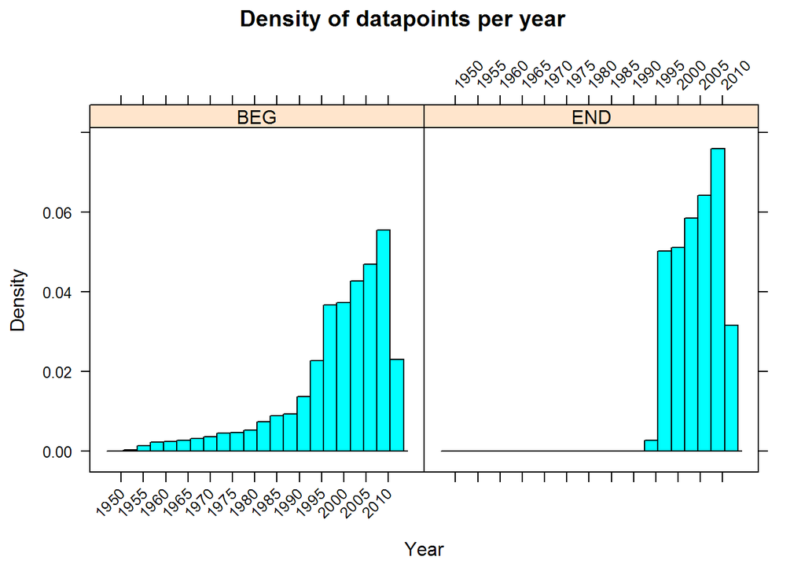

```r
histogram(~Date|BGN.END, data = years, type = "density",
          scales = list(x = list(at = seq(1950, 2010, by = 5), rot = 45)),
          main = "Density of datapoints per year", xlab = "Year")
```

The above histograms show the density of recorded datapoints per year.

The figure clearly show that in the years prior to 1995, beginning date entries were more sparse, and end date entries were mostly non-existent. Thus, the most complete information is available for years after 1995. The data was then subsetted for 1995 onwards. The end date was arbitrarily selected as the criterion for subsetting and for marking the event. As such, a given weather event in this analsyis is measured by the date it subsided.

```r
stormdata <- stormdata[which(as.numeric(format(END_DATE, "%Y")) >= 1995)]
stormdata$BGN_DATE <- NULL
setcolorder(stormdata, c("END_DATE", "EVTYPE", "FATALITIES",
                         "INJURIES", "PROPDMG", "PROPDMGEXP", "CROPDMG",
                         "CROPDMGEXP"))
setnames(stormdata, old = names(stormdata), new = c("Date", "Event",
                                                    "Fatalities", "Injuries",
                                                    "Propdamage", "PROPDMGEXP",
                                                    "Cropdamage", "CROPDMGEXP"))
rm(bYears)
rm(eYears)
rm(years)
tables()
```

[output not shown]

### Transforming the data - *events*

The Event variable was examined for unnecessary information and for overall categories.

```r
length(unique(stormdata$Event))
```

```
## [1] 626
```

```r
head(unique(stormdata$Event))
```

```
## [1] SNOW                      SNOW/ICE
## [3] HURRICANE OPAL/HIGH WINDS HURRICANE OPAL
## [5] THUNDERSTORM WINDS        HAIL
## 985 Levels:    HIGH SURF ADVISORY  COASTAL FLOOD ... WND
```

```r
tail(unique(stormdata$Event))
```

```
## [1] DENSE SMOKE              LAKESHORE FLOOD
## [3] MARINE THUNDERSTORM WIND MARINE STRONG WIND
## [5] ASTRONOMICAL LOW TIDE    VOLCANIC ASHFALL
## 985 Levels:    HIGH SURF ADVISORY  COASTAL FLOOD ... WND
```

```r
stormdata <- stormdata[!grep("Summary", Event)]

setkey(stormdata, Event)

stormdata <- stormdata[which(Fatalities > 0 & Injuries > 0 & Propdamage > 0 &
                                     Cropdamage > 0)]
tables()
```

[output not shown]

```r
unique(stormdata$Event)
```

```
##  [1] EXCESSIVE HEAT          FLASH FLOOD
##  [3] FLOOD                   HEAT
##  [5] HEAT WAVE DROUGHT       HEAVY SNOW
##  [7] HIGH WIND               HURRICANE
##  [9] HURRICANE/TYPHOON       THUNDERSTORM WIND
## [11] TORNADO                 TROPICAL STORM
## [13] TSTM WIND               TSUNAMI
## [15] WILDFIRE                WINTER STORM
## [17] WINTER STORM HIGH WINDS
## 985 Levels:    HIGH SURF ADVISORY  COASTAL FLOOD ... WND
```

- Heat events (HEAT, HEAT WAVE DROUGHT, WILDFIRE)
- Flood events (FLOOD, FLASH FLOOD, TSUNAMI)
- Rain events (HURRICANE/TYPHOON, TROPICAL STORM)
- Wind events (HIGH WIND, THUNDERSTORM WIND, TORNADO, WINTER STORM HIGH WINDS)
- Winter events (HEAVY SNOW, WINTER STORM)

```r
stormdata[Event == "TSTM WIND"]$Event <- "THUNDERSTORM WIND"
stormdata[Event == "HURRICANE"]$Event <- "HURRICANE/TYPHOON"
stormdata[Event == "EXCESSIVE HEAT"]$Event <- "HEAT"
unique(stormdata$Event)
```

```
##  [1] HEAT                    FLASH FLOOD
##  [3] FLOOD                   HEAT WAVE DROUGHT
##  [5] HEAVY SNOW              HIGH WIND
##  [7] HURRICANE/TYPHOON       THUNDERSTORM WIND
##  [9] TORNADO                 TROPICAL STORM
## [11] TSUNAMI                 WILDFIRE
## [13] WINTER STORM            WINTER STORM HIGH WINDS
## 985 Levels:    HIGH SURF ADVISORY  COASTAL FLOOD ... WND
```

```r
stormdata$EventType <- ""

Heat <- c("HEAT", "HEAT WAVE DROUGHT", "WILDFIRE")
Flood <- c("FLOOD", "FLASH FLOOD", "TSUNAMI")
Rain <- c("HURRICANE/TYPHOON", "TROPICAL STORM")
Wind <- c("HIGH WIND", "THUNDERSTORM WIND", "TORNADO", "WINTER STORM HIGH WINDS")
Winter <- c("HEAVY SNOW", "WINTER STORM")

stormdata[Event%in%Heat]$EventType <- "Heat"
stormdata[Event%in%Flood]$EventType <- "Flood"
stormdata[Event%in%Rain]$EventType <- "Rain"
stormdata[Event%in%Wind]$EventType <- "Wind"
stormdata[Event%in%Winter]$EventType <- "Winter"

stormdata$EventType <- as.factor(stormdata$EventType)
head(stormdata)
```

```
##          Date       Event Fatalities Injuries Propdamage PROPDMGEXP
## 1: 2006-07-27        HEAT         46       18      170.0          K
## 2: 1995-06-23 FLASH FLOOD          1        1        2.0          M
## 3: 1995-06-23 FLASH FLOOD          1        2        1.0          M
## 4: 1998-08-24 FLASH FLOOD          9      150       40.0          M
## 5: 1998-10-18 FLASH FLOOD          1       50        1.5          M
## 6: 2003-07-06 FLASH FLOOD          1        1       50.0          K
##    Cropdamage CROPDMGEXP EventType
## 1:      492.4          M      Heat
## 2:      100.0          K     Flood
## 3:      300.0          K     Flood
## 4:      100.0          K     Flood
## 5:      100.0          K     Flood
## 6:      750.0          K     Flood
```

```r
tail(stormdata)
```

```
##          Date                   Event Fatalities Injuries Propdamage
## 1: 2003-10-31                WILDFIRE          2       18      55.22
## 2: 2006-03-01                WILDFIRE          1        7      15.00
## 3: 2006-03-18                WILDFIRE         12        8      49.90
## 4: 2009-04-12                WILDFIRE          2        1       5.00
## 5: 1998-01-14            WINTER STORM          4        8     140.00
## 6: 1995-12-12 WINTER STORM HIGH WINDS          1       15      60.00
##    PROPDMGEXP Cropdamage CROPDMGEXP EventType
## 1:          M       22.0          M      Heat
## 2:          M      250.0          K      Heat
## 3:          M       45.4          M      Heat
## 4:          M        1.0          M      Heat
## 5:          K       20.0          K    Winter
## 6:          M        5.0          M      Wind
```

### Transforming the data - *damages*

The data on damages was transformed in two ways: (1) to correct the economic damages (property and crop damage) for the factor of ten provided in the variables PROPDMGEXP and CROPDMGEXP, and (2) to combine the damage variables as one variable with four levels: Fatality, Injury, Property and Crop. These transformations were performed to allow for more elegant graphical analysis.

1. Correcting for factor of 10 in economic damages

```r
unique(stormdata$PROPDMGEXP)
```

```
## [1] K M B
## Levels:  - ? + 0 1 2 3 4 5 6 7 8 B h H K m M
```

```r
unique(stormdata$CROPDMGEXP)
```

```
## [1] M K B
## Levels:  ? 0 2 B k K m M
```

```r
stormdata$PEXP <- 0
stormdata$CEXP <- 0

stormdata[PROPDMGEXP == "K"]$PEXP <- 10^3
stormdata[PROPDMGEXP == "M"]$PEXP <- 10^6
stormdata[PROPDMGEXP == "B"]$PEXP <- 10^9

stormdata[CROPDMGEXP == "K"]$CEXP <- 10^3
stormdata[CROPDMGEXP == "M"]$CEXP <- 10^6
stormdata[CROPDMGEXP == "B"]$CEXP <- 10^9

stormdata$Propdamage <- stormdata$Propdamage*stormdata$PEXP
stormdata$Cropdamage <- stormdata$Cropdamage*stormdata$CEXP

stormdata$PROPDMGEXP <- NULL
stormdata$CROPDMGEXP <- NULL
stormdata$PEXP <- NULL
stormdata$CEXP <- NULL

damages <- rbind(data.table("Damage" = stormdata$Fatalities,
                            "DamageType" = "Health",
                            "DamageType2" = "Fatality"),
                 data.table("Damage" = stormdata$Injuries,
                            "DamageType" = "Health",
                            "DamageType2" = "Injury"),
                 data.table("Damage" = stormdata$Propdamage,
                            "DamageType" = "Economic",
                            "DamageType2" = "Property"),
                 data.table("Damage" = stormdata$Cropdamage,
                            "DamageType" = "Economic",
                            "DamageType2" = "Crop"))

stormdata <- cbind(stormdata, damages)

stormdata$Fatalities <- NULL
stormdata$Injuries <- NULL
stormdata$Propdamage <- NULL
stormdata$Cropdamage <- NULL

stormdata$DamageType <- as.factor(stormdata$DamageType)
stormdata$DamageType2 <- as.factor(stormdata$DamageType2)
```

The final dataset is completely clean.

```r
stormdata
```

```
##            Date                   Event EventType   Damage DamageType
##   1: 2006-07-27                    HEAT      Heat       46     Health
##   2: 1995-06-23             FLASH FLOOD     Flood        1     Health
##   3: 1995-06-23             FLASH FLOOD     Flood        1     Health
##   4: 1998-08-24             FLASH FLOOD     Flood        9     Health
##   5: 1998-10-18             FLASH FLOOD     Flood        1     Health
##  ---
## 340: 2006-03-01                WILDFIRE      Heat   250000   Economic
## 341: 2006-03-18                WILDFIRE      Heat 45400000   Economic
## 342: 2009-04-12                WILDFIRE      Heat  1000000   Economic
## 343: 1998-01-14            WINTER STORM    Winter    20000   Economic
## 344: 1995-12-12 WINTER STORM HIGH WINDS      Wind  5000000   Economic
##      DamageType2
##   1:    Fatality
##   2:    Fatality
##   3:    Fatality
##   4:    Fatality
##   5:    Fatality
##  ---
## 340:        Crop
## 341:        Crop
## 342:        Crop
## 343:        Crop
## 344:        Crop
```